# Diagnosed depression among adults in Finland, Poland and Spain

Dataset 14: Quality of life among adults in Finland, Poland and Spain (COURAGE)

RSR feasibility analysis

2026-08-03

# Introduction

COURAGE in Europe is a cross-sectional survey of the general community-dwelling adult population of Finland, Poland and Spain, designed to describe healthy ageing and its social and environmental determinants; the source paper is Miret and colleagues, *PLOS ONE* (2016). The file distributed with this catalogue holds 5341 participants aged 18 to 104 (mean 57.8 years), of whom 765 (14.3%) report having been diagnosed with depression. Depression is the leading cause of years lived with disability in European adults and is heavily under-diagnosed in older people, so identifying which social, physical and national characteristics mark higher diagnosed prevalence is a standard question in ageing research.

**Aim.** Among these adults in Finland, Poland and Spain, we examined which of age, sex, country, urban or rural residence, education, marital status, physical activity, social network, bodily pain, arthritis, angina and diabetes are independently associated with having a diagnosis of depression, mutually adjusting for the others.

This is a *Purpose 3* analysis: several predictors are of interest and the question is which remain associated with the outcome after mutual adjustment.

# Methods

**Data source.** COURAGE in Europe, a cross-sectional multistage stratified cluster sample of the community-dwelling adult populations of Finland, Poland and Spain, fielded between 2011 and 2012. The deposited S1 file used here contains 5341 participants and 38 variables: 2632 from Poland, 2076 from Spain and 633 from Finland.

**Variables.** The outcome is `depression_diagnosis`, a binary indicator where the **event is a reported diagnosis of depression** (765 events in the full file, 14.3%). Predictors are age (years), sex (reference female), country (reference Poland, the largest group), residence (reference urban), education dichotomised as high school or higher versus none, primary or secondary (reference the latter), marital status (reference married or cohabiting), physical activity (reference high), the social network index (0-100), bodily pain in five ordered categories (reference none) and diagnosed arthritis, angina and diabetes (each reference no).

**`depression_diagnosis` appears in the catalogue’s own predictor list and has been removed from it.** It is the outcome here; regressing a variable on itself is not an analysis. This is worth stating explicitly because the suggested-predictor list shipped with the dataset does contain it, and a student copying that list verbatim will produce a model with an infinite coefficient.

**`sadness` and `sleep_difficulty` are excluded as symptoms of the outcome.** Depressed mood and sleep disturbance are two of the nine diagnostic criteria for a major depressive episode, so a model in which they “predict” a depression diagnosis is measuring the outcome twice rather than explaining it. The association is strong but, importantly, **not deterministic**: among participants reporting severe or extreme sadness, 42.7% report a depression diagnosis, against 8.3% of those reporting none - a strong gradient (Cramer’s V 0.273, chi-squared p <0.001) but nowhere near a one-to-one mapping, and no cell of the cross-tabulation is empty. So this is *not* a separation problem that R would warn about; it is a conceptual problem that only subject-matter reasoning catches, which makes it more dangerous rather than less. Adding `sadness` to the final model raises Tjur’s R-squared from 0.121 to 0.164 and gives severe or extreme sadness an odds ratio of about 7.1 - i.e. it “works” beautifully, which is exactly why it is tempting. The cross-tabulation is shown in the Results.

**The predictor set is deliberately cut.** Excluding the outcome, the catalogue suggests 20 predictors. Most are multi-level factors, so entering all of them costs **38 estimated parameters**, not 20: `body_pain` alone costs four, and `marital_status`, `alcohol_use`, `sleep_difficulty`, `sadness` and `distance_vision_difficulty` cost three each. With 765 events that is 20.1 events per parameter, which still clears the conventional minimum of ten - so on this outcome too the global events-per-parameter rule does not by itself force the cut, and a student who fits everything will see no warning. What does force it is the combination of four things: a 38-row odds ratio table cannot be interpreted; testing 38 coefficients at 0.05 means expecting about 1.9 significant results by chance; two of the suggested predictors are symptoms of the outcome; and the *global* events-per-parameter figure hides the fact that individual levels are thin - the `frequent_heavy` alcohol category has 35 participants and 9 events, and crossed with country it contains a **zero-event cell** (11 Polish heavy-frequent drinkers, none with a depression diagnosis), which produces complete separation in any model that interacts the two. The set used here costs **19 parameters**, i.e. 40.3 events per parameter, and was fixed before any model was fitted.

Six further suggested predictors are dropped. `bmi_category`, `smoking_status` and `alcohol_use` are behaviours whose relationship with a *diagnosis* of depression is weak and heavily bidirectional, and `alcohol_use` carries the sparse-level problem above. `distance_vision_difficulty` costs three parameters for a functional limitation whose smallest stratum holds 136 people. `neighbourhood_usability` and `home_usability` are environmental scales whose natural outcome in this dataset is quality of life rather than a clinical diagnosis; `social_network_index` is retained as the one psychosocial scale with a well-established literature linking it to depression.

**Level collapsing.** Five categorical predictors were checked for sparse strata. `education` had 125 participants with no or informal education, of whom 124 live in Spain and **none** in Finland; it was collapsed to two levels, because a category that exists in one country only cannot be separated from country. `alcohol_use` would have needed collapsing (`frequent_heavy`, 35 participants) but is dropped for the reasons above. `marital_status` (smallest level 477), `bmi_category` (1485) and `physical_activity` (1437) were large enough to keep as supplied, and the thinnest retained cell is 81 events, so there is no zero cell and no separation.

**Statistical analysis.** `glm(family = binomial)`, justified because the outcome is binary. We fitted a univariable model for each predictor first, then a single multivariable model containing all of them. Predictors were chosen in advance on subject-matter grounds, not by significance. Coefficients are exponentiated and reported as odds ratios with 95% confidence intervals; significance threshold 0.05. Model adequacy was assessed with `performance::check_model()`, focusing on binned residuals, collinearity, influential observations and events per parameter. Models are **unweighted**: the COURAGE sampling weights, strata and clusters are not carried in this file, so no result here is a nationally representative estimate. Analysis used R version 4.6.0 (2026-04-24) with tidyverse, gtsummary and performance.

**Missing data.** There is none. All 38 columns are 100% complete in this file and 5341 of 5341 rows are complete on every variable, so the complete-case analysis uses 5341 of 5341 rows (0 dropped), leaving 765 events. Listwise deletion costs nothing here, so the predictor cut rests entirely on interpretability and causal-structure grounds.

# Results

## Sample characteristics

**Table 1. Sample characteristics by depression diagnosis.**

| **Characteristic** | **N** | **No depression diagnosis** N = 4,576<sup>1</sup> | **Depression diagnosis** N = 765<sup>1</sup> |
| --- | --- | --- | --- |
| Age (years) | 5,341 | 60 (49, 70) | 61 (53, 69) |
| Sex | 5,341 |  |  |
| Female |  | 2,519 (55%) | 583 (76%) |
| Male |  | 2,057 (45%) | 182 (24%) |
| Country | 5,341 |  |  |
| Poland |  | 2,370 (52%) | 262 (34%) |
| Spain |  | 1,664 (36%) | 412 (54%) |
| Finland |  | 542 (12%) | 91 (12%) |
| Residence | 5,341 |  |  |
| Urban |  | 3,506 (77%) | 625 (82%) |
| Rural |  | 1,070 (23%) | 140 (18%) |
| Education | 5,341 |  |  |
| None, primary or secondary |  | 2,278 (50%) | 467 (61%) |
| High school or higher |  | 2,298 (50%) | 298 (39%) |
| Marital status | 5,341 |  |  |
| Married or cohabiting |  | 2,711 (59%) | 374 (49%) |
| Never married |  | 758 (17%) | 81 (11%) |
| Separated or divorced |  | 345 (7.5%) | 132 (17%) |
| Widowed |  | 762 (17%) | 178 (23%) |
| Physical activity | 5,341 |  |  |
| High |  | 2,097 (46%) | 296 (39%) |
| Moderate |  | 1,274 (28%) | 237 (31%) |
| Low |  | 1,205 (26%) | 232 (30%) |
| Social network index (0-100) | 5,341 | 69 (60, 78) | 67 (57, 76) |
| Bodily pain | 5,341 |  |  |
| None |  | 1,957 (43%) | 180 (24%) |
| Pain without difficulty |  | 631 (14%) | 85 (11%) |
| Mild difficulty |  | 877 (19%) | 153 (20%) |
| Moderate difficulty |  | 738 (16%) | 191 (25%) |
| Severe or extreme difficulty |  | 373 (8.2%) | 156 (20%) |
| Diagnosed arthritis | 5,341 | 1,054 (23%) | 316 (41%) |
| Diagnosed angina | 5,341 | 325 (7.1%) | 86 (11%) |
| Diagnosed diabetes | 5,341 | 499 (11%) | 108 (14%) |

<sup>1</sup> Median (Q1, Q3); n (%)

Participants with a depression diagnosis are much more often women (76% versus 55%), much more often Spanish (54% versus 36%), and carry a far heavier pain burden (20% report severe or extreme pain-related difficulty versus 8%). Median age is almost identical in the two groups (61 versus 60 years), which is the first sign that the crude age association is weak and will change under adjustment.

## The `sadness` cross-tabulation

**Table 2. `sadness` against `depression_diagnosis` (excluded predictor).**

| Sadness severity | No depression diagnosis | Depression diagnosis | Total | % with diagnosis |
| --- | --- | --- | --- | --- |
| None | 2818 | 254 | 3072 | 8.3 |
| Mild | 1016 | 170 | 1186 | 14.3 |
| Moderate | 557 | 203 | 760 | 26.7 |
| Severe or extreme | 185 | 138 | 323 | 42.7 |

The gradient is steep and monotonic, from 8.3% in the no-sadness group to 42.7% in the severe group, but the relationship is far from deterministic - most participants reporting severe or extreme sadness have **no** recorded depression diagnosis, and 8.3% of those reporting no sadness do have one. Every cell is populated, so nothing here would trigger a separation warning. `sadness` is excluded on the conceptual grounds set out in Methods, not because the model refuses to fit it.

## Exploratory figure

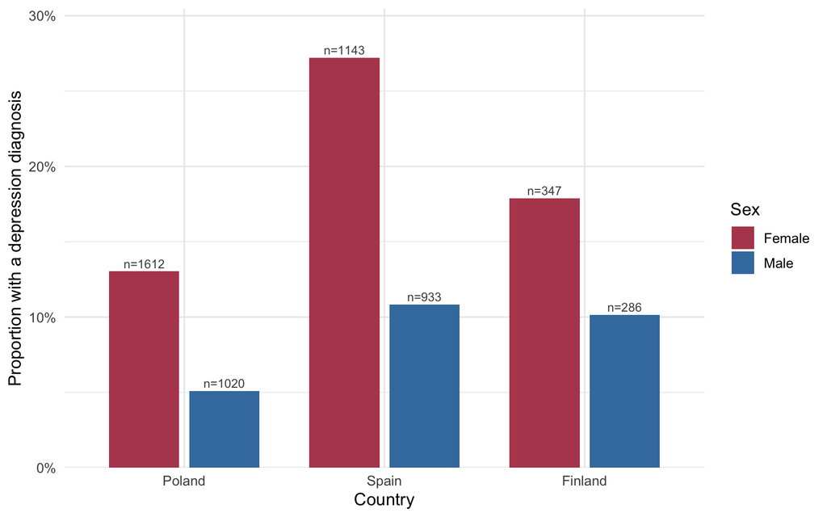

Figure 1. Proportion with a depression diagnosis by country and sex.

Diagnosed depression is roughly twice as common in Spain (19.8%) as in Poland (10.0%), with Finland in between (14.4%), and within every country women are diagnosed far more often than men; the sex gap is proportionally similar in all three, which argues against strong effect modification by country on this particular contrast.

## Univariable models

| **Characteristic** | **N** | **OR** | **95% CI** | **p-value** |
| --- | --- | --- | --- | --- |
| Age (years) | 5,341 | 1.01 | 1.00, 1.01 | <0.001 |
| Sex | 5,341 |  |  |  |
| Female |  | — | — |  |
| Male |  | 0.38 | 0.32, 0.46 | <0.001 |
| Country | 5,341 |  |  |  |
| Poland |  | — | — |  |
| Spain |  | 2.24 | 1.90, 2.65 | <0.001 |
| Finland |  | 1.52 | 1.17, 1.95 | 0.001 |
| Residence | 5,341 |  |  |  |
| Urban |  | — | — |  |
| Rural |  | 0.73 | 0.60, 0.89 | 0.002 |
| Education | 5,341 |  |  |  |
| None, primary or secondary |  | — | — |  |
| High school or higher |  | 0.63 | 0.54, 0.74 | <0.001 |
| Marital status | 5,341 |  |  |  |
| Married or cohabiting |  | — | — |  |
| Never married |  | 0.77 | 0.60, 0.99 | 0.048 |
| Separated or divorced |  | 2.77 | 2.20, 3.48 | <0.001 |
| Widowed |  | 1.69 | 1.39, 2.06 | <0.001 |
| Physical activity | 5,341 |  |  |  |
| High |  | — | — |  |
| Moderate |  | 1.32 | 1.10, 1.58 | 0.003 |
| Low |  | 1.36 | 1.13, 1.64 | 0.001 |
| Social network index (0-100) | 5,341 | 0.99 | 0.98, 0.99 | <0.001 |
| Bodily pain | 5,341 |  |  |  |
| None |  | — | — |  |
| Pain without difficulty |  | 1.46 | 1.11, 1.92 | 0.006 |
| Mild difficulty |  | 1.90 | 1.51, 2.39 | <0.001 |
| Moderate difficulty |  | 2.81 | 2.26, 3.51 | <0.001 |
| Severe or extreme difficulty |  | 4.55 | 3.57, 5.79 | <0.001 |
| Diagnosed arthritis | 5,341 |  |  |  |
| No |  | — | — |  |
| Yes |  | 2.35 | 2.00, 2.76 | <0.001 |
| Diagnosed angina | 5,341 |  |  |  |
| No |  | — | — |  |
| Yes |  | 1.66 | 1.28, 2.12 | <0.001 |
| Diagnosed diabetes | 5,341 |  |  |  |
| No |  | — | — |  |
| Yes |  | 1.34 | 1.07, 1.67 | 0.010 |

Abbreviations: CI = Confidence Interval, OR = Odds Ratio

Sex shows the strongest crude association: men have OR 0.38 (95% CI 0.32 to 0.46) (p <0.001) of a depression diagnosis relative to women, a reduction of about 62% in the odds. Bodily pain shows a steep monotonic gradient, from OR 1.46 (95% CI 1.11 to 1.92) for pain without difficulty (p = 0.006) to OR 4.55 (95% CI 3.57 to 5.79) for severe or extreme pain-related difficulty (p <0.001). Separation or divorce carries OR 2.77 (95% CI 2.20 to 3.48) (p <0.001) and widowhood OR 1.69 (95% CI 1.39 to 2.06) (p <0.001) relative to being married or cohabiting. Arthritis is associated with OR 2.35 (95% CI 2.00 to 2.76) (p <0.001), angina with OR 1.66 (95% CI 1.28 to 2.12) (p <0.001) and diabetes with OR 1.34 (95% CI 1.07 to 1.67) (p = 0.010). Spanish participants have OR 2.24 (95% CI 1.90 to 2.65) (p <0.001) and Finnish participants OR 1.52 (95% CI 1.17 to 1.95) (p = 0.001) relative to Polish participants. Each additional point of the social network index is associated with OR 0.99 (95% CI 0.98 to 0.99) (p <0.001), which compounds to about 23% lower odds across a 20-point difference. Low physical activity carries OR 1.36 (95% CI 1.13 to 1.64) (p = 0.001) and higher education OR 0.63 (95% CI 0.54 to 0.74) (p <0.001). Two crude results should be flagged in advance as unstable: **rural residence appears protective** (OR 0.73 (95% CI 0.60 to 0.89), p = 0.002), and **each year of age is associated with slightly *higher* odds** (OR 1.01 (95% CI 1.00 to 1.01), p <0.001) - both reverse or vanish on adjustment.

## Why adjustment is needed

**Country** is the confounder that matters most here, and it explains the rural result directly. Rural residence is overwhelmingly a Polish phenomenon in this sample: 36% of Polish participants live rurally against 10% of Spanish participants, and Poland has by far the lowest diagnosed prevalence (10.0% against 19.8% in Spain). The crude protective rural odds ratio is therefore a statement about which country people live in, not about rurality. The same argument applies to education and to the social network index, both of which differ markedly between the three national samples.

**Age** is the second, and it works in the opposite direction from the usual case. Older participants are far more likely to be widowed (median age 74 against 59 for the married or cohabiting), to report bodily pain and to have arthritis, and all of those are associated with a depression diagnosis. Age therefore *inflates* the crude widowhood, arthritis and pain coefficients, while the crude age coefficient itself is propped up by exactly those variables. Holding pain, arthritis and marital status constant should push the age coefficient below one - which is what happens, and is consistent with under-diagnosis of depression in the oldest old. **Bodily pain** is a third: it is associated with arthritis, angina, low physical activity and widowhood as well as with the outcome, so it will absorb part of each of those coefficients. Mutual adjustment lets each odds ratio be read as a comparison between participants of the same age, sex, country, residence, education, marital status, activity level, social network, pain and chronic disease status.

## Multivariable model

| **Characteristic** | **OR** | **95% CI** | **p-value** |
| --- | --- | --- | --- |
| Age (years) | 0.98 | 0.98, 0.99 | <0.001 |
| Sex |  |  |  |
| Female | — | — |  |
| Male | 0.43 | 0.35, 0.52 | <0.001 |
| Country |  |  |  |
| Poland | — | — |  |
| Spain | 3.89 | 3.14, 4.83 | <0.001 |
| Finland | 2.24 | 1.63, 3.05 | <0.001 |
| Residence |  |  |  |
| Urban | — | — |  |
| Rural | 1.02 | 0.81, 1.26 | 0.9 |
| Education |  |  |  |
| None, primary or secondary | — | — |  |
| High school or higher | 0.85 | 0.71, 1.02 | 0.087 |
| Marital status |  |  |  |
| Married or cohabiting | — | — |  |
| Never married | 0.76 | 0.57, 1.00 | 0.050 |
| Separated or divorced | 2.26 | 1.75, 2.91 | <0.001 |
| Widowed | 1.12 | 0.88, 1.42 | 0.3 |
| Physical activity |  |  |  |
| High | — | — |  |
| Moderate | 1.05 | 0.85, 1.28 | 0.7 |
| Low | 0.92 | 0.74, 1.13 | 0.4 |
| Social network index (0-100) | 0.98 | 0.97, 0.99 | <0.001 |
| Bodily pain |  |  |  |
| None | — | — |  |
| Pain without difficulty | 1.25 | 0.92, 1.68 | 0.15 |
| Mild difficulty | 1.77 | 1.38, 2.26 | <0.001 |
| Moderate difficulty | 2.93 | 2.28, 3.78 | <0.001 |
| Severe or extreme difficulty | 4.61 | 3.44, 6.17 | <0.001 |
| Diagnosed arthritis |  |  |  |
| No | — | — |  |
| Yes | 1.58 | 1.30, 1.91 | <0.001 |
| Diagnosed angina |  |  |  |
| No | — | — |  |
| Yes | 1.41 | 1.06, 1.88 | 0.018 |
| Diagnosed diabetes |  |  |  |
| No | — | — |  |
| Yes | 1.03 | 0.80, 1.31 | 0.8 |

Abbreviations: CI = Confidence Interval, OR = Odds Ratio

**Model fit: multivariable logistic model for diagnosed depression**

| Statistic | Value |
| --- | --- |
| Complete-case N | 5341 |
| Events (depression_diagnosis = 1) | 765 |
| Parameters (excl. intercept) | 19 |
| Events per parameter | 40.3 |
| AIC (null model) | 4390.0 |
| AIC (full model) | 3853.7 |
| Tjur's R-squared | 0.121 |

The model has 765 events for 19 estimated parameters, i.e. **40.3 events per parameter**, four times the conventional minimum, so over-fitting is not a concern. AIC falls from 4390.0 for the intercept-only model to 3853.7, a drop of 536.3, but Tjur’s R-squared is only 0.121 - the predictors carry real information yet discriminate poorly between individuals, which is what one would expect of a diagnosis that depends heavily on unmeasured help-seeking behaviour.

Among participants of the same age, sex, residence, education, marital status, activity level, social network, pain and chronic disease status, **country is the largest contrast in the model**: Spanish participants have OR 3.89 (95% CI 3.14 to 4.83) (p <0.001) and Finnish participants OR 2.24 (95% CI 1.63 to 3.05) (p <0.001) relative to Polish participants. Men have OR 0.43 (95% CI 0.35 to 0.52) (p <0.001), i.e. roughly 57% lower odds than women. Bodily pain retains its full gradient, from OR 1.77 (95% CI 1.38 to 2.26) for mild difficulty (p <0.001) to OR 4.61 (95% CI 3.44 to 6.17) for severe or extreme difficulty (p <0.001). Separation or divorce carries OR 2.26 (95% CI 1.75 to 2.91) (p <0.001), arthritis OR 1.58 (95% CI 1.30 to 1.91) (p <0.001) and angina OR 1.41 (95% CI 1.06 to 1.88) (p = 0.018). Each point of the social network index is associated with OR 0.98 (95% CI 0.97 to 0.99) (p <0.001), about 34% lower odds across 20 points. Age now runs the other way: each additional year is associated with OR 0.98 (95% CI 0.98 to 0.99) (p <0.001). Rural residence (OR 1.02 (95% CI 0.81 to 1.26)), education (OR 0.85 (95% CI 0.71 to 1.02)), widowhood (OR 1.12 (95% CI 0.88 to 1.42)), diabetes (OR 1.03 (95% CI 0.80 to 1.31)) and both physical-activity contrasts (OR 0.92 (95% CI 0.74 to 1.13) for low activity) are not independently associated. These are associations among the participants observed, not effects of intervening.

**Statistical against practical significance.** With 5341 observations and 765 events, this model has power to detect associations too small to be useful. Age is the clearest case: OR 0.98 (95% CI 0.98 to 0.99) per year is significant (p <0.001) but corresponds to only 14% lower odds per decade, which no clinician would act on. Angina (OR 1.41 (95% CI 1.06 to 1.88), p = 0.018) is a second: significant, but the confidence interval runs from 1.06 to 1.88, so the data are compatible with a nearly negligible association. Contrast those with the Spain contrast (OR 3.89 (95% CI 3.14 to 4.83)), the sex contrast (OR 0.43 (95% CI 0.35 to 0.52)) and severe pain (OR 4.61 (95% CI 3.44 to 6.17)), which are large enough to change how one would think about service planning. At this sample size, statistical significance separates “non-zero” from “zero”, not “important” from “unimportant”.

## Unadjusted versus adjusted

**Table 3. Unadjusted and adjusted odds ratios.**

| **Characteristic** | **Unadjusted** **N** | **Unadjusted** **OR** | **Unadjusted** **95% CI** | **Unadjusted** **p-value** | **Adjusted** **OR** | **Adjusted** **95% CI** | **Adjusted** **p-value** |
| --- | --- | --- | --- | --- | --- | --- | --- |
| Age (years) | 5,341 | 1.01 | 1.00, 1.01 | <0.001 | 0.98 | 0.98, 0.99 | <0.001 |
| Sex | 5,341 |  |  |  |  |  |  |
| Female |  | — | — |  | — | — |  |
| Male |  | 0.38 | 0.32, 0.46 | <0.001 | 0.43 | 0.35, 0.52 | <0.001 |
| Country | 5,341 |  |  |  |  |  |  |
| Poland |  | — | — |  | — | — |  |
| Spain |  | 2.24 | 1.90, 2.65 | <0.001 | 3.89 | 3.14, 4.83 | <0.001 |
| Finland |  | 1.52 | 1.17, 1.95 | 0.001 | 2.24 | 1.63, 3.05 | <0.001 |
| Residence | 5,341 |  |  |  |  |  |  |
| Urban |  | — | — |  | — | — |  |
| Rural |  | 0.73 | 0.60, 0.89 | 0.002 | 1.02 | 0.81, 1.26 | 0.9 |
| Education | 5,341 |  |  |  |  |  |  |
| None, primary or secondary |  | — | — |  | — | — |  |
| High school or higher |  | 0.63 | 0.54, 0.74 | <0.001 | 0.85 | 0.71, 1.02 | 0.087 |
| Marital status | 5,341 |  |  |  |  |  |  |
| Married or cohabiting |  | — | — |  | — | — |  |
| Never married |  | 0.77 | 0.60, 0.99 | 0.048 | 0.76 | 0.57, 1.00 | 0.050 |
| Separated or divorced |  | 2.77 | 2.20, 3.48 | <0.001 | 2.26 | 1.75, 2.91 | <0.001 |
| Widowed |  | 1.69 | 1.39, 2.06 | <0.001 | 1.12 | 0.88, 1.42 | 0.3 |
| Physical activity | 5,341 |  |  |  |  |  |  |
| High |  | — | — |  | — | — |  |
| Moderate |  | 1.32 | 1.10, 1.58 | 0.003 | 1.05 | 0.85, 1.28 | 0.7 |
| Low |  | 1.36 | 1.13, 1.64 | 0.001 | 0.92 | 0.74, 1.13 | 0.4 |
| Social network index (0-100) | 5,341 | 0.99 | 0.98, 0.99 | <0.001 | 0.98 | 0.97, 0.99 | <0.001 |
| Bodily pain | 5,341 |  |  |  |  |  |  |
| None |  | — | — |  | — | — |  |
| Pain without difficulty |  | 1.46 | 1.11, 1.92 | 0.006 | 1.25 | 0.92, 1.68 | 0.15 |
| Mild difficulty |  | 1.90 | 1.51, 2.39 | <0.001 | 1.77 | 1.38, 2.26 | <0.001 |
| Moderate difficulty |  | 2.81 | 2.26, 3.51 | <0.001 | 2.93 | 2.28, 3.78 | <0.001 |
| Severe or extreme difficulty |  | 4.55 | 3.57, 5.79 | <0.001 | 4.61 | 3.44, 6.17 | <0.001 |
| Diagnosed arthritis | 5,341 |  |  |  |  |  |  |
| No |  | — | — |  | — | — |  |
| Yes |  | 2.35 | 2.00, 2.76 | <0.001 | 1.58 | 1.30, 1.91 | <0.001 |
| Diagnosed angina | 5,341 |  |  |  |  |  |  |
| No |  | — | — |  | — | — |  |
| Yes |  | 1.66 | 1.28, 2.12 | <0.001 | 1.41 | 1.06, 1.88 | 0.018 |
| Diagnosed diabetes | 5,341 |  |  |  |  |  |  |
| No |  | — | — |  | — | — |  |
| Yes |  | 1.34 | 1.07, 1.67 | 0.010 | 1.03 | 0.80, 1.31 | 0.8 |

Abbreviations: CI = Confidence Interval, OR = Odds Ratio

**Age** is the coefficient that changes most fundamentally: it reverses direction, from OR 1.01 (95% CI 1.00 to 1.01) crude (p <0.001, higher odds with age) to OR 0.98 (95% CI 0.98 to 0.99) adjusted (p <0.001, lower odds with age). This is exactly the confounding structure anticipated above - the crude positive slope was carried by pain, arthritis and widowhood, all of which accumulate with age, and once they are held constant the residual age association is protective, most plausibly because depression is under-recognised in the oldest participants. **Rural residence** does something similar: from OR 0.73 (95% CI 0.60 to 0.89) (p = 0.002, apparently protective and significant) to OR 1.02 (95% CI 0.81 to 1.26) (p = 0.887, exactly null). The whole crude association was country. **Widowhood** collapses from OR 1.69 (95% CI 1.39 to 2.06) (p <0.001) to OR 1.12 (95% CI 0.88 to 1.42) (p = 0.349), losing significance: widows are old and in pain, and neither of those is caused by widowhood in any useful sense. **Arthritis** attenuates from OR 2.35 (95% CI 2.00 to 2.76) to OR 1.58 (95% CI 1.30 to 1.91), **diabetes** from OR 1.34 (95% CI 1.07 to 1.67) (p = 0.010) to OR 1.03 (95% CI 0.80 to 1.31) (p = 0.837, null), and **low physical activity** from OR 1.36 (95% CI 1.13 to 1.64) (p = 0.001) to OR 0.92 (95% CI 0.74 to 1.13) (p = 0.411, null) - in each case bodily pain and age absorb the crude association.

Two estimates move **away** from the null. **Spain** goes from OR 2.24 (95% CI 1.90 to 2.65) to OR 3.89 (95% CI 3.14 to 4.83), and **Finland** from OR 1.52 (95% CI 1.17 to 1.95) to OR 2.24 (95% CI 1.63 to 3.05): the Polish sample is more rural and more often in pain, which was masking part of the national gap, so adjustment widens it. By contrast the two strongest predictors **barely move at all**. Severe or extreme pain goes from OR 4.55 (95% CI 3.57 to 5.79) to OR 4.61 (95% CI 3.44 to 6.17) - essentially unchanged, retaining 102% of its crude excess odds - and sex from OR 0.38 (95% CI 0.32 to 0.46) to OR 0.43 (95% CI 0.35 to 0.52). Neither is explained by anything else measured here. One estimate crosses out of significance without moving far: education, from OR 0.63 (95% CI 0.54 to 0.74) (p <0.001) to OR 0.85 (95% CI 0.71 to 1.02) (p = 0.087), because most of the crude educational gradient was country and age.

## Diagnostics

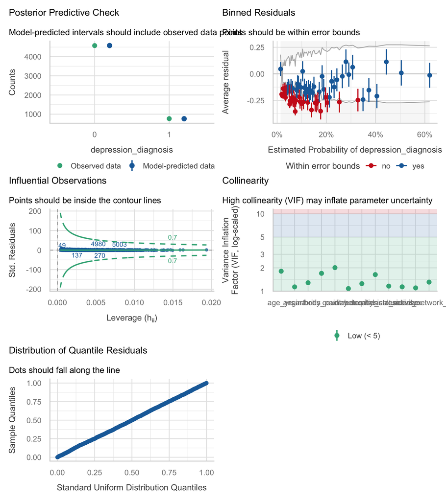

```
## Warning: Probably bad model fit. Only about 52% of the residuals are inside the error bounds.
```

| Term | VIF | VIF_CI_low | VIF_CI_high | SE_factor | Tolerance | Tolerance_CI_low | Tolerance_CI_high |
| --- | --- | --- | --- | --- | --- | --- | --- |
| age_yrs | 1.811254 | 1.744156 | 1.884402 | 1.345828 | 0.5521038 | 0.5306725 | 0.5733433 |
| sex | 1.102811 | 1.075168 | 1.140620 | 1.050148 | 0.9067737 | 0.8767164 | 0.9300872 |
| country | 2.014638 | 1.936880 | 2.098849 | 1.191377 | 0.4963672 | 0.4764516 | 0.5162943 |
| residence | 1.137609 | 1.107441 | 1.176249 | 1.066588 | 0.8790363 | 0.8501599 | 0.9029829 |
| education | 1.251546 | 1.214444 | 1.295068 | 1.118725 | 0.7990115 | 0.7721604 | 0.8234219 |
| marital_status | 1.637228 | 1.579292 | 1.700958 | 1.085638 | 0.6107884 | 0.5879038 | 0.6331949 |
| physical_activity | 1.163064 | 1.131231 | 1.202619 | 1.038487 | 0.8597979 | 0.8315183 | 0.8839929 |
| social_network_index | 1.309515 | 1.269162 | 1.355918 | 1.144340 | 0.7636416 | 0.7375078 | 0.7879217 |
| body_pain | 1.700959 | 1.639662 | 1.768130 | 1.068653 | 0.5879036 | 0.5655691 | 0.6098820 |
| arthritis | 1.286029 | 1.246982 | 1.331249 | 1.134032 | 0.7775874 | 0.7511740 | 0.8019363 |

[output cut: 2 more lines]

**Table 4. Separation, influence and collinearity checks.**

| Check | Value |
| --- | --- |
| Largest \|coefficient\| (log-odds) | 1.53 |
| Largest standard error | 0.335 |
| Largest VIF | 2.01 |
| Largest Cook's distance | 0.0033 |
| Largest leverage | 0.019 |
| Smallest event count in any predictor level | 81 |
| Binned residuals inside bounds | 52% |

The binned-residual check is the diagnostic that matters for a logistic model and it **fails badly**: only about 52% of binned residuals fall inside the error bounds against a target of 95% or more, and `performance` prints a “probably bad model fit” warning. This is the worst calibration of the three models in this dataset, and with 5341 observations it is not a small-bin artefact. The model systematically under-predicts at some parts of the probability range and over-predicts at others, which is consistent with a Tjur’s R-squared of only 0.121: the linear predictor simply does not separate the 765 cases from the 4576 non-cases well. Collinearity is not a problem: the largest VIF is 2.01 for country, comfortably below the conventional threshold of 5, although it is the highest of the three models here and reflects the entanglement of country with residence and education described earlier. Influence is negligible: the largest Cook’s distance is 0.0033 and the largest leverage 0.019. There is **no separation**: every coefficient is finite, the largest standard error is 0.335, and every level of every categorical predictor contains events (Table 4). Homogeneity of variance and normality of residuals do not apply to a logistic model and are not interpreted; the corresponding panels of `check_model()` should be ignored here.

# Discussion

Among these 5341 adults in Finland, Poland and Spain, the characteristics most strongly and independently associated with having a depression diagnosis are country, sex and bodily pain. Spanish participants have about 3.9 times the odds of otherwise similar Polish participants, men about 57% lower odds than women, and participants with severe or extreme pain-related difficulty about 4.6 times the odds of those with no pain. Separation or divorce, arthritis and a poorer social network are also independently associated. The crude associations with rural residence, widowhood, diabetes, low physical activity and education all disappear on adjustment, and the crude *positive* age association reverses. Practically, the results point at chronic pain and social disconnection as the two modifiable characteristics most closely tracking diagnosed depression, and they underline how much of the variation is between countries rather than between individuals - a 3.9-fold difference in diagnosis odds between two European countries, unexplained by any individual characteristic measured here, is more likely to be a statement about health systems than about mental health.

**The outcome is a *diagnosis*, not depression.** Being counted as a case requires having consulted a clinician, having been assessed, and having been given a label. Under-diagnosis in older adults, in men and in countries with less accessible primary mental-health care will all be misclassified as absence of disease. That makes the reversed age coefficient (OR 0.98 (95% CI 0.98 to 0.99)) genuinely ambiguous: it is at least as plausible that depression is *under-recognised* in the oldest participants as that they are less depressed. The country contrasts are open to exactly the same reading. Bodily pain is the other interpretive difficulty: pain and depression are bidirectionally related, chronic pain is a recognised consequence of depression as well as a cause of it, and in a cross-sectional survey nothing distinguishes the two directions.

**Limitations.** The models are **unweighted**: the COURAGE sampling weights, strata and clusters are not carried in this file, so the sample must not be described as representative of any national population, and the standard errors ignore clustering within primary sampling units, which will make them too narrow. The design is cross-sectional, so reverse causation is live for bodily pain, physical activity, social network and marital status alike - depression plausibly causes social withdrawal, inactivity and relationship breakdown as readily as the reverse. The outcome is self-reported diagnosis, with the differential misclassification by age, sex, country and healthcare access described above. Two suggested predictors, `sadness` and `sleep_difficulty`, were excluded because they are diagnostic criteria for the outcome rather than causes of it, and `depression_diagnosis` itself had to be removed from the catalogue’s suggested predictor list; six others were excluded a priori, so residual confounding by smoking, alcohol, body mass and vision is certain. The binned-residual check fails (52% inside bounds) and Tjur’s R-squared is 0.121, so the model is poorly calibrated and discriminates weakly; its coefficients describe average contrasts, not a usable prediction rule. There is evidence of effect modification the additive model ignores: country-by-age (likelihood-ratio p = 0.004) and country-by-marital-status (p = 0.029) both improve the fit, so the single age slope reported here averages over three different national gradients; country-by-sex does not (p = 0.188), consistent with Figure 1. The deposited file differs from the published paper: it holds 5341 rows with mean age 57.8 years, whereas the source paper reports 5,639 participants with mean age 46.3 years, so results here should not be compared with the published analysis. The `education` variable was collapsed to two levels, hiding any effect confined to the 125 participants with no formal education. With 5341 observations, small and practically uninteresting differences reach significance. All estimates are associations, not causal effects.

**Future work.** Refit with the COURAGE survey design (weights, strata and clusters) and with the study’s symptom-based depression algorithm rather than self-reported diagnosis, which would remove the help-seeking filter that dominates the country and age contrasts here.

# Feasibility notes

*NOT part of a student report.*

- **USABLE WITH WARNINGS.** 765 events in 5341 complete rows, no missing data anywhere, 40.3 events per parameter at 19 parameters, no separation, no influential points (max Cook’s 0.0033), max VIF 2.01. The warnings are about interpretation and calibration, not about whether the model can be fitted.
- **FATAL if uncorrected: `depression_diagnosis` is in `meta.json`’s own suggested predictor list for this dataset.** A student copying that list gets the outcome as a predictor of itself. `build/meta.json` should drop it from `predictors`, or the dataset page should carry an explicit note. This is the single most likely way this outcome is wrecked, and it is our error, not the student’s.
- **MAJOR: `sadness` is a symptom of the outcome, and it is NOT detectable as a data problem.** Cramer’s V 0.273; 42.7% of the severe-sadness group has a diagnosis against 8.3% of the no-sadness group, every cell populated, no separation, no warning of any kind. Adding it raises Tjur’s R-squared from 0.121 to 0.164 and gives severe sadness an odds ratio of about 7.1. It will look like the best finding in the report. `sleep_difficulty` has the same problem more weakly (sleep disturbance is a diagnostic criterion for major depression). Both should be flagged on the dataset page as not-predictors for this outcome.
- **MAJOR: binned residuals fail badly** - only 52% inside bounds against a 95% target, the worst of the three outcomes, with a “probably bad model fit” warning. Tjur’s R-squared 0.121. A student following the diagnostics honestly must report a failed check and a weakly discriminating model.
- **MAJOR: 20 usable suggested predictors cost 38 parameters, not 20.** At 765 events that is 20.1 events per parameter, which *passes* the rule of ten, so the full model fits with no warning. The global EPP figure is therefore misleading here; what matters is the individual cell counts.
- **MAJOR: the file does not match the paper.** 5341 rows, mean age 57.8, median 60, range 18-104; the paper reports 5,639 participants with mean age 46.3. Verified directly from the CSV. The dataset page should carry an explicit caution.
- **MAJOR trap: separation via `country * alcohol_use`.** `frequent_heavy` has 35 participants in total, and the Poland stratum has **11 participants with 0 depression events**. Fitting `glm(depression_diagnosis ~ country * alcohol_use)` produces a coefficient of -12.6 with a standard error of about 266 - textbook complete separation - and a “fitted probabilities numerically 0 or 1” warning. Even without the interaction, `frequent_heavy` carries only 9 events. `alcohol_use` should be collapsed or dropped.
- **MINOR but structural: `education == "none_or_informal"` is a Spain-only category** - 124 of 125 are Spanish, **zero** are Finnish. Interacted with `country` it separates. Collapsed to two levels here.
- **MINOR: the crude age association reverses on adjustment** (OR 1.01 (95% CI 1.00 to 1.01) to OR 0.98 (95% CI 0.98 to 0.99)). Excellent teaching material for confounding, but a weak student will report one direction in the univariable section and the opposite in the multivariable section without noticing.
- **MINOR: unmodelled effect modification by country.** country-by-age likelihood-ratio p = 0.004, country-by-marital-status p = 0.029. Country is the strongest predictor in the model and is doing more than shifting the intercept.
- **Unweighted survey analysis.** Must be stated in Methods and Limitations.